# ASS4

Chih-Yu

2024-04-15

# Task list

## Question 1 (8.1)

```r
s <- matrix( c(5,2,2,2), nrow = 2, byrow=TRUE)
pca <- princomp(covmat=s)
summary(pca)
```

```
## Importance of components:
##                           Comp.1    Comp.2
## Standard deviation     2.4494897 1.0000000
## Proportion of Variance 0.8571429 0.1428571
## Cumulative Proportion  0.8571429 1.0000000
```

85.71% of the population variance is explained by the first principal component.

```r
pca$loadings
```

```
##
## Loadings:
##      Comp.1 Comp.2
## [1,]  0.894  0.447
## [2,]  0.447 -0.894
##
##                Comp.1 Comp.2
## SS loadings       1.0    1.0
## Proportion Var    0.5    0.5
## Cumulative Var    0.5    1.0
```

$Y_1 = 0.894X_1 + 0.447X_2$  
$Y_2 = 0.447X_1 - 0.894X_2$

## Question 2(8.2)

### a. correlation matrix p

```r
# convert covariance matrix to correlation matrix
d = sqrt(diag(s))
D <- diag(d)
# find inverse of D
# same as same as matrix(c(d[1], 0, 0, d[2]), nrow = 2, byrow=TRUE)
Dinv <- solve(D)
p <- Dinv %*% s %*% Dinv
round(p, 4)
```

```
##        [,1]   [,2]
## [1,] 1.0000 0.6325
## [2,] 0.6325 1.0000
```

```r
# the whole thing is same as cov2cor(s)
```

#### method 1

```r
eigen(p)
```

```
## eigen() decomposition
## $values
## [1] 1.6324555 0.3675445
##
## $vectors
##            [,1]       [,2]
## [1,] -0.7071068  0.7071068
## [2,] -0.7071068 -0.7071068
```

```r
proportion<- eigen(p)$value[1] / sum(eigen(p)$value)
proportion
```

```
## [1] 0.8162278
```

#### method 2

```r
pc <- princomp(covmat = p, cor = TRUE)
pc$loading
```

```
##
## Loadings:
##      Comp.1 Comp.2
## [1,]  0.707  0.707
## [2,]  0.707 -0.707
##
##                Comp.1 Comp.2
## SS loadings       1.0    1.0
## Proportion Var    0.5    0.5
## Cumulative Var    0.5    1.0
```

```r
summary(pc)
```

```
## Importance of components:
##                           Comp.1    Comp.2
## Standard deviation     1.2776758 0.6062545
## Proportion of Variance 0.8162278 0.1837722
## Cumulative Proportion  0.8162278 1.0000000
```

Two method show the same result. 81.62% of the population variance is explained by the first principal component.  
$Y_1 = 0.707X_1 + 0.707X_2$  
$Y_2 = 0.707X_1 - 0.707X_2$

### b. compare teh result

The result are different. It is because they are obtain from the different linear transformation matrix (cor and cov). However, they indeed represent the same underlying data set.

### c. correlation

```r
p11 <- pc$loading[1,1] * sqrt(eigen(p)$value[1])
round(p11, 4)
```

```
## Comp.1
## 0.9035
```

```r
p12 <- pc$loading[1,2] * sqrt(eigen(p)$value[1])
round(p12, 4)
```

```
## Comp.2
## 0.9035
```

```r
p21 <- pc$loading[2,1] * sqrt(eigen(p)$value[2])
round(p21, 4)
```

```
## Comp.1
## 0.4287
```

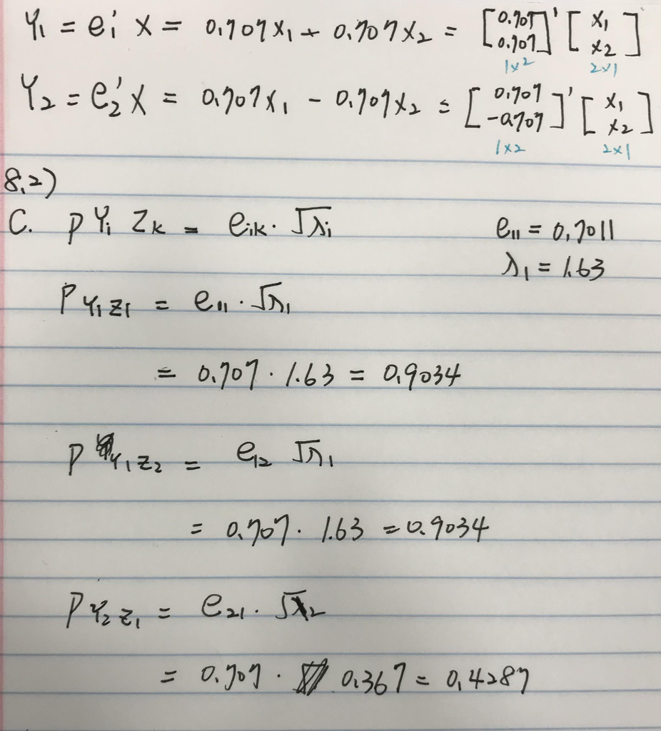

## Question 3 (8.3)

```r
S <- matrix( c(2,0,0,
               0,4,0,
               0,0,4), nrow=3, byrow= TRUE)
eigen(S)
```

```
## eigen() decomposition
## $values
## [1] 4 4 2
##
## $vectors
##      [,1] [,2] [,3]
## [1,]    0    0    1
## [2,]    0    1    0
## [3,]    1    0    0
```

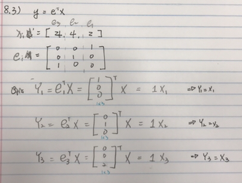

## Question 5 (8.5)

### a

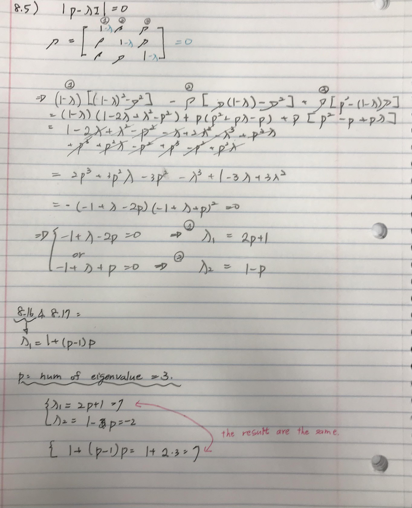

### b

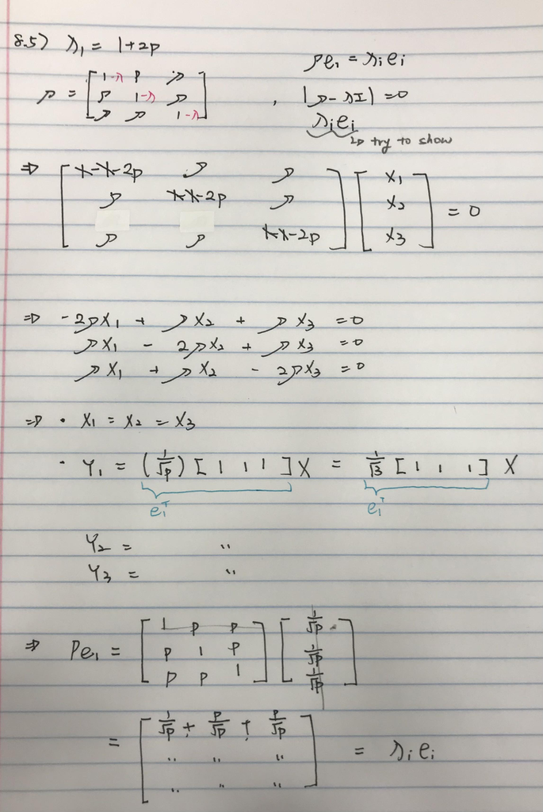

## Question 6 (8.6)

```r
x1 <- MATH4793CHUAssignment::sales
x2 <- MATH4793CHUAssignment::profits

x<-matrix(c(x1, x2), byrow=FALSE)

Xmean <- matrix(c(155.60, 14.7), nrow=2, byrow=TRUE)
Xmean
```

```
##       [,1]
## [1,] 155.6
## [2,]  14.7
```

```r
Xcov <- matrix(c(7476.45,303.62, 303.62, 26.19), nrow=2, byrow=TRUE)
Xcov
```

```
##         [,1]   [,2]
## [1,] 7476.45 303.62
## [2,]  303.62  26.19
```

### a. principle component

```r
e<-eigen(Xcov)
e
```

```
## eigen() decomposition
## $values
## [1] 7488.80293   13.83707
##
## $vectors
##             [,1]        [,2]
## [1,] -0.99917337  0.04065185
## [2,] -0.04065185 -0.99917337
```

### b. proportion

```r
y <- prcomp(Xcov)
summary(y)
```

```
## Importance of components:
##                         PC1      PC2
## Standard deviation     5076 2.84e-14
## Proportion of Variance    1 0.00e+00
## Cumulative Proportion     1 1.00e+00
```

```r
p<- 7488.80293/(7488.80293+13.83707)
p
```

```
## [1] 0.9981557
```

99.81557% can be explain by the first principle component

### c. density elliose

```r
Sinv <- solve(Xcov)
Sinv
```

```
##               [,1]         [,2]
## [1,]  0.0002527428 -0.002930041
## [2,] -0.0029300411  0.072150404
```

```r
FactoMineR::PCA(x,scale.unit = FALSE)
```

[output not shown]

```
## **Results for the Principal Component Analysis (PCA)**
## The analysis was performed on 20 individuals, described by 1 variables
## *The results are available in the following objects:
##
##    name               description
## 1  "$eig"             "eigenvalues"
## 2  "$var"             "results for the variables"
## 3  "$var$coord"       "coord. for the variables"
## 4  "$var$cor"         "correlations variables - dimensions"
## 5  "$var$cos2"        "cos2 for the variables"
## 6  "$var$contrib"     "contributions of the variables"
## 7  "$ind"             "results for the individuals"
## 8  "$ind$coord"       "coord. for the individuals"
## 9  "$ind$cos2"        "cos2 for the individuals"
## 10 "$ind$contrib"     "contributions of the individuals"
## 11 "$call"            "summary statistics"
## 12 "$call$centre"     "mean of the variables"
## 13 "$call$ecart.type" "standard error of the variables"
## 14 "$call$row.w"      "weights for the individuals"
## 15 "$call$col.w"      "weights for the variables"
```

The first principle compontent will explain for almost 99% of the variables

### d. correlation

```r
j <- nrow(eigen(Xcov)$vector)
ri <- sqrt(diag(Xcov))
corre <- sapply(1:j, function(k) {
  eigen(Xcov)$vector[k, 1] * sqrt(eigen(Xcov)$value[1]) / ri[k]
})
corre[1]
```

```
## [1] -0.9999985
```

```r
corre[2]
```

```
## [1] -0.6874146
```

## Question 7 (8.7)

## a. principle components

```r
Xcor <- cov2cor(Xcov)
Xcor
```

```
##           [,1]      [,2]
## [1,] 1.0000000 0.6861434
## [2,] 0.6861434 1.0000000
```

```r
eigen(Xcor)
```

```
## eigen() decomposition
## $values
## [1] 1.6861434 0.3138566
##
## $vectors
##           [,1]       [,2]
## [1,] 0.7071068 -0.7071068
## [2,] 0.7071068  0.7071068
```

```r
pp<- princomp(covmat = Xcor)
pp$loading
```

```
##
## Loadings:
##      Comp.1 Comp.2
## [1,]  0.707  0.707
## [2,]  0.707 -0.707
##
##                Comp.1 Comp.2
## SS loadings       1.0    1.0
## Proportion Var    0.5    0.5
## Cumulative Var    0.5    1.0
```

### b.

```r
1.6861434/(1.6861434+0.3138566)
```

```
## [1] 0.8430717
```

the first principle component could explain 84.31% of the variance/

###c.

```r
l<-princomp(covmat = Xcor)$loading
cor11 <- l[1, 1]
cor21 <- l[2, 1]
cor11
```

```
##    Comp.1
## 0.7071068
```

```r
cor21
```

```
##    Comp.1
## 0.7071068
```

## Question 9 (8.10)

### a. cov matrix and principal components

```r
x <- read.table("T8-4.dat")
#  construct the sample covariance matrix
S <- cov(x)
S
```

```
##              V1           V2           V3           V4           V5
## V1 4.332695e-04 0.0002756679 1.590265e-04 6.411929e-05 8.896616e-05
## V2 2.756679e-04 0.0004387172 1.799737e-04 1.814512e-04 1.232623e-04
## V3 1.590265e-04 0.0001799737 2.239722e-04 7.341348e-05 6.054612e-05
## V4 6.411929e-05 0.0001814512 7.341348e-05 7.224964e-04 5.082772e-04
## V5 8.896616e-05 0.0001232623 6.054612e-05 5.082772e-04 7.656742e-04
```

```r
# principal components
pcaX <- prcomp(x, scale = FALSE)
summary(pcaX)
```

```
## Importance of components:
##                            PC1     PC2     PC3     PC4     PC5
## Standard deviation     0.03698 0.02648 0.01593 0.01194 0.01090
## Proportion of Variance 0.52926 0.27133 0.09822 0.05518 0.04601
## Cumulative Proportion  0.52926 0.80059 0.89881 0.95399 1.00000
```

```r
pcaX$rotation
```

```
##           PC1        PC2         PC3        PC4         PC5
## V1 -0.2228228 -0.6252260 -0.32611218 -0.6627590 -0.11765952
## V2 -0.3072900 -0.5703900  0.24959014  0.4140935  0.58860803
## V3 -0.1548103 -0.3445049  0.03763929  0.4970499 -0.78030428
## V4 -0.6389680  0.2479475  0.64249741 -0.3088689 -0.14845546
## V5 -0.6509044  0.3218478 -0.64586064  0.2163758  0.09371777
```

### b.proportion of the first three

```r
pro<-princomp(x, cor = FALSE)
pro
```

```
## Call:
## princomp(x = x, cor = FALSE)
##
## Standard deviations:
##     Comp.1     Comp.2     Comp.3     Comp.4     Comp.5
## 0.03680217 0.02635056 0.01585365 0.01188352 0.01085046
##
##  5  variables and  103 observations.
```

```r
summary(pro)
```

```
## Importance of components:
##                            Comp.1     Comp.2     Comp.3     Comp.4     Comp.5
## Standard deviation     0.03680217 0.02635056 0.01585365 0.01188352 0.01085046
## Proportion of Variance 0.52926066 0.27133298 0.09821584 0.05518400 0.04600652
## Cumulative Proportion  0.52926066 0.80059364 0.89880948 0.95399348 1.00000000
```

The first comp. could explain 52.93% of the variables; the second comp. could explain 27.13% of the variables; the third comp. could explain 9.82% of variables. 89.88% of the total variances could be explained by the first three comp.

### c. 90% confidence interval

```r
# using 8-33
# get lambda
eigen(S)$value
```

```
## [1] 0.0013676780 0.0007011596 0.0002538024 0.0001426026 0.0001188868
```

```r
# 90% ci, get alpha
alpha = 0.1
# n = total num of observation
n <- nrow(x)
# p = num of variable
p <- length(x)
ci <- matrix(nrow=2, ncol=p)
for (i in 1:p){
  z <- qnorm(1 - alpha/(2) )
  # calculate ci with 8-33
  upper <- eigen(S)$value[i]/(1-z*sqrt(2/n))
  lower <- eigen(S)$value[i]/(1+z*sqrt(2/n))
  ci[1,i] <- upper
  ci[2,i] <- lower
}
rownames(ci) <- c("Upper Bound", "Lower Bound")
ci
```

```
##                    [,1]         [,2]         [,3]         [,4]         [,5]
## Upper Bound 0.001774373 0.0009096574 0.0003292735 0.0001850071 1.542391e-04
## Lower Bound 0.001112653 0.0005704172 0.0002064769 0.0001160121 9.671846e-05
```

### d. summarzie

Yes, it can be explain with 3 principle component. It is mainly because the first three can explain about 90% of the variance.

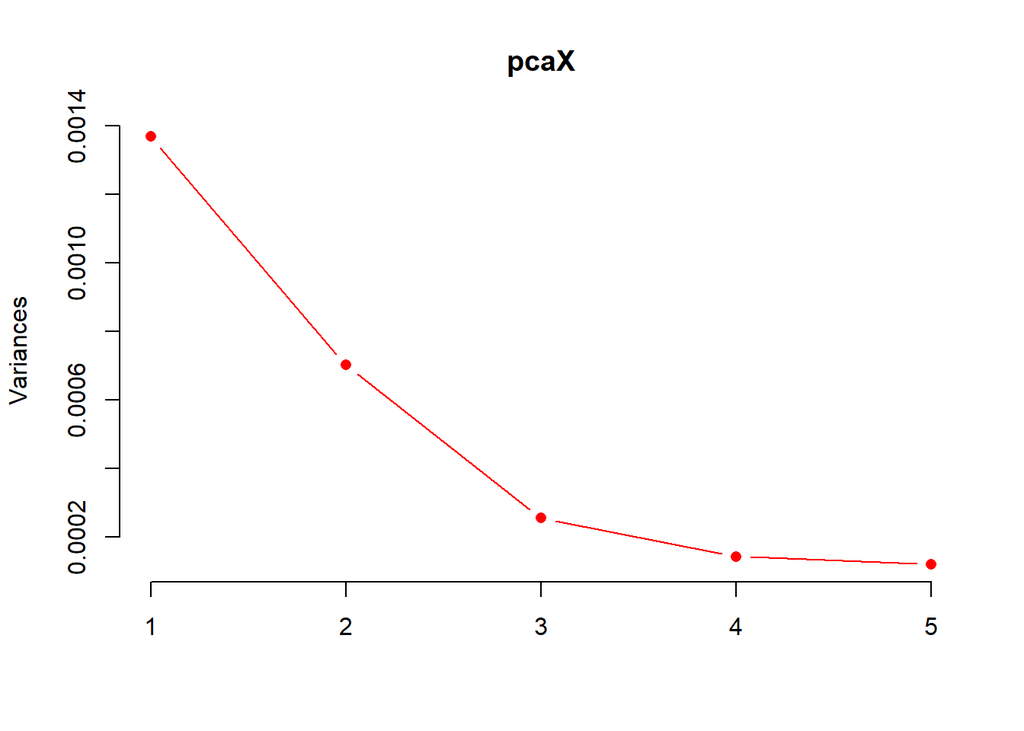

```r
screeplot(pcaX, col = "red", pch = 16,type = "lines")
```

## Question 10 (8.11)

### a.

```r
x <- read.table("T8-5.dat")
so<-cov(x)
so
```

```
##             V1        V2           V3          V4          V5
## V1  3.39689902 -1.102139   4.30555484  -2.0782852  0.02720391
## V2 -1.10213937  9.672775  -1.51323628  10.9532322  1.20306366
## V3  4.30555484 -1.513236  55.62591164 -28.9374642 -0.04355907
## V4 -2.07828525 10.953232 -28.93746421  89.0666120  0.95729973
## V5  0.02720391  1.203064  -0.04355907   0.9572997  0.31862508
```

### b.

```r
eigen(so)
```

```
## eigen() decomposition
## $values
## [1] 107.0152535  39.6721358   8.3708660   2.8678740   0.1546931
##
## $vectors
##              [,1]        [,2]        [,3]        [,4]         [,5]
## [1,]  0.038887287 -0.07114494 -0.18789258  0.97713524 -0.057699864
## [2,] -0.105321969 -0.12975236  0.96099580  0.17135181 -0.138554092
## [3,]  0.492363944 -0.86438807 -0.04579737 -0.09104368  0.004966048
## [4,] -0.863069865 -0.48033178 -0.15318538 -0.02968577  0.006691800
## [5,] -0.009122262 -0.01474342  0.12498114  0.08170118  0.988637470
```

### c.

```r
po<-princomp(x, cor = FALSE)
summary(po)
```

```
## Importance of components:
##                            Comp.1    Comp.2     Comp.3     Comp.4       Comp.5
## Standard deviation     10.2596737 6.2467410 2.86943177 1.67954149 0.3900732431
## Proportion of Variance  0.6769654 0.2509611 0.05295308 0.01814182 0.0009785696
## Cumulative Proportion   0.6769654 0.9279265 0.98087961 0.99902143 1.0000000000
```